# Detect phases of the day

Joffrey JOUMAA

April 27, 2023

We’ll like to find something similar to what was done for the individual `2004023`, that is to say find the different phase of the day: day and night, by identifying the sunrise and the sunset. For that we’ll try the function previously used in `2004023` and apply it to 2018 individuals. Then we’ll try other methods and decide which method fit the most our needs. Our ultimate goal is to be able to plot this kind of figure:

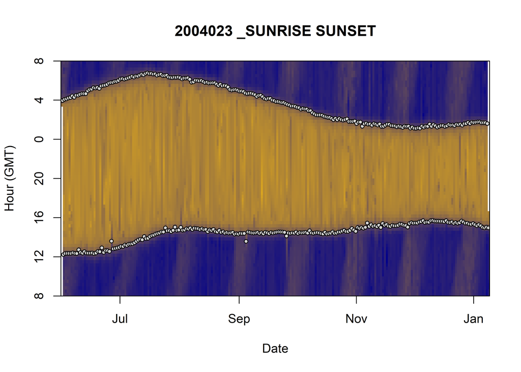

## 0.1 Display the data of 2018-individuals

Let’s first load our package and our data.

```r
# load library
library(ontodive)

# load data
data_nes <- get_data("nes")

# combine all individuals
data_2018 <- rbindlist(data_nes$year_2018, use.name = TRUE, idcol = TRUE)

# remove phase column for the purpose of this document
data_2018[, phase := NULL]
```

To visualize the data, we summarize each point on the plot as the median of the light level during one hour of one day.

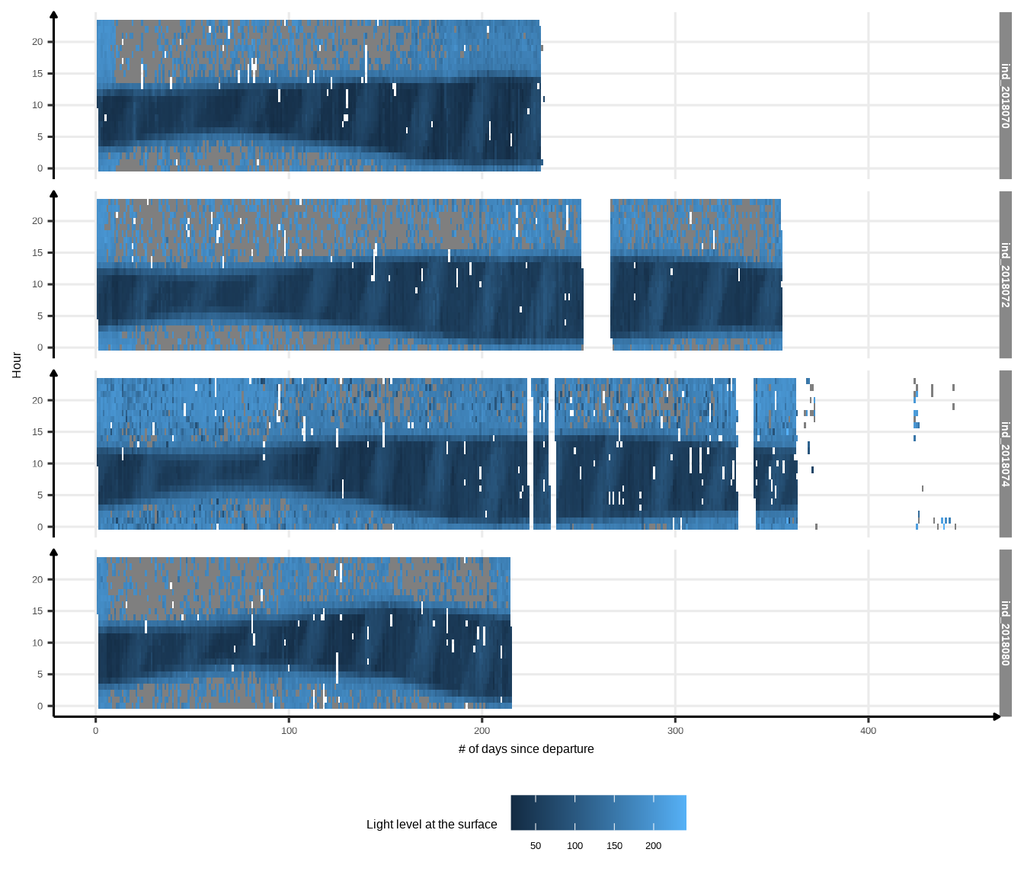

Figure 1: Visualization of light level at the surface along 2018-individuals’ trip

```r
# let's first average `lightatsurf` by individuals, day since departure and hour
dataPlot <- data_2018[, .(lightatsurf = median(lightatsurf, na.rm = T)),
  by = .(.id, day_departure, date = as.Date(date), hour = hour(date))
]

# display the result
ggplot(dataPlot, aes(x = day_departure, y = hour, fill = lightatsurf)) +
  geom_tile() +
  facet_grid(.id ~ .) +
  theme_jjo() +
  labs(x = "# of days since departure", y = "Hour", fill = "Light level at the surface") +
  theme(legend.position = c("bottom"))
```

> Why is there so much data with missing value during day time?

Well, the good news is that we can clearly see the same pattern we saw in `2004023`. Let’s look at the distribution

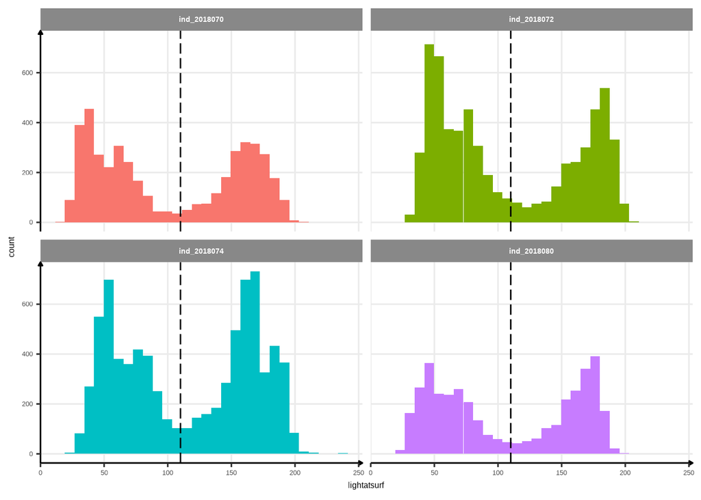

Figure 2: Distribution of `lightatsurf` with a threshold at 110.

```r
# display the result
ggplot(dataPlot, aes(x = lightatsurf, fill = .id)) +
  geom_histogram(show.legend = FALSE) +
  geom_vline(xintercept = 110, linetype = "longdash") +
  facet_wrap(.id ~ .) +
  theme_jjo()
```

There is a bimodal distribution for each individual that seems to be quite well separated by a threshold at `110`, which correspond to the threshold that has been used for the individual `2004023`. In 2018 individuals, 110 seems also to be an appropriate value.

## 0.2 Let’s give a try to the `findTwilights` function

Let’s first reshape our data to complied with the `findTwilights` function.

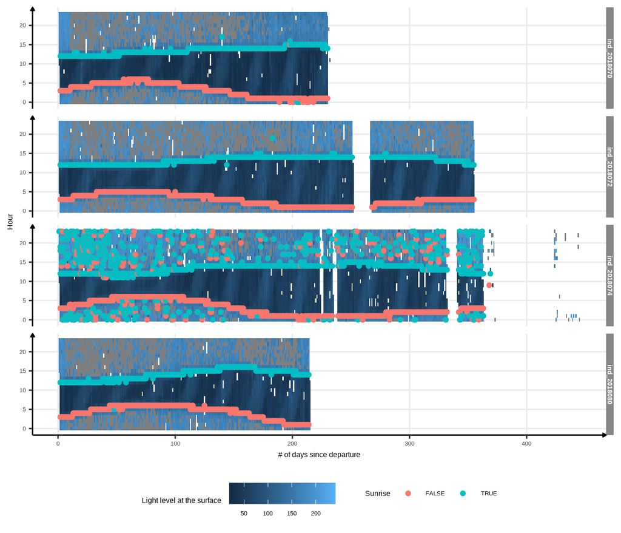

Figure 3: Visualization of light level at the surface along 2018-individuals’ trip, with twilight detection points

```r
# identification of sunset, sunrise pairs
res_twi <- data_2018[!is.na(lightatsurf),
  findTwilights(.(Date = date, Light = lightatsurf),
    threshold = 110, include = date
  ),
  by = .id
]

# add `day_departure` to res_twi using a rolling join
# https://www.r-bloggers.com/2016/06/understanding-data-table-rolling-joins/
res_twi <- data_2018[, .(.id, Twilight = date, day_departure)] %>%
  .[res_twi, roll = T, on = c(".id", "Twilight")] %>%
  # hour column
  .[, hour := hour(Twilight)]

# display the result
ggplot() +
  geom_tile(data = dataPlot, aes(x = day_departure, y = hour, fill = lightatsurf)) +
  geom_point(data = res_twi, aes(x = day_departure, y = hour, col = Rise)) +
  facet_grid(.id ~ .) +
  theme_jjo() +
  labs(
    x = "# of days since departure",
    y = "Hour",
    fill = "Light level at the surface",
    col = "Sunrise"
  ) +
  theme(legend.position = c("bottom"))
```

Not bad actually! But there are many outliers that need to be addressed. Let’s try to only keep the pair `Rise` (`TRUE`, `FALSE`) that has the longer period of time of the day.

```r
# calculate the period of time between a sunrise and a sunset (i.e. two consecutive rows)
res_twi[, period_time := c(0, as.numeric(diff(Twilight, units = "hours"),
  units = "mins"
)),
by = .(.id, as.Date(Twilight))
]

# keep only the longer period of time and the row just before
res_twi_inter <- res_twi[
  c(
    # index of row with the longer period of time
    res_twi[, .I[period_time == max(period_time)],
      by = .(.id, as.Date(Twilight))
    ]$V1,
    # index of the row previous the one with the longer period of time
    res_twi[, .I[period_time == max(period_time)],
      by = .(.id, as.Date(Twilight))
    ]$V1 - 1
  )
] %>%
  # reorder by date
  .[order(Twilight)]
```

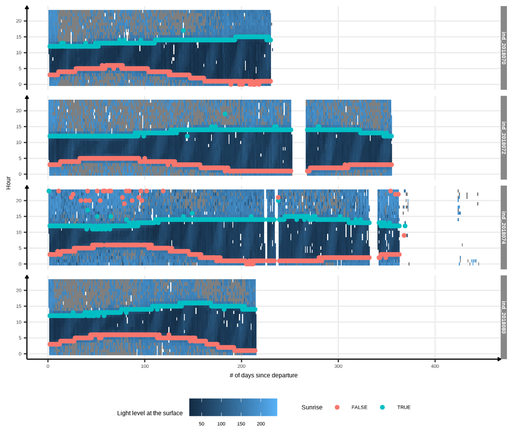

Figure 4: Visualization of light level at the surface along 2018-individuals’ trip, with twilight detection points corrected

```r
# display the result
ggplot() +
  geom_tile(data = dataPlot, aes(x = day_departure, y = hour, fill = lightatsurf)) +
  geom_point(data = res_twi_inter, aes(x = day_departure, y = hour, col = Rise)) +
  facet_grid(.id ~ .) +
  theme_jjo() +
  labs(
    x = "# of days since departure",
    y = "Hour",
    fill = "Light level at the surface",
    col = "Sunrise"
  ) +
  theme(legend.position = c("bottom"))
```

That’s definitely better, but there are few remaining outliers (especially for the individual `ind_2018074`). Let’s zoom in the first days since departure for this individual, to see what’s going on.

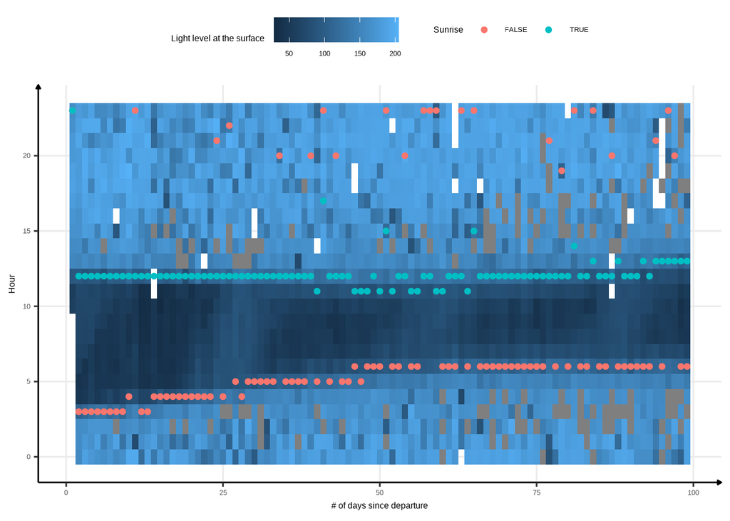

```r
# display the result
ggplot() +
  geom_tile(
    data = dataPlot[.id == "ind_2018074" & day_departure < 100, ],
    aes(x = day_departure, y = hour, fill = lightatsurf)
  ) +
  geom_point(
    data = res_twi_inter[.id == "ind_2018074" & day_departure < 100],
    aes(x = day_departure, y = hour, col = Rise)
  ) +
  theme_jjo() +
  labs(
    x = "# of days since departure",
    y = "Hour",
    fill = "Light level at the surface",
    col = "Sunrise"
  ) +
  theme(legend.position = c("top"))
```

As we can see, some low light levels are encountered in the middle of daytime that mislead the `findTwilight` function in finding the sunrise or the sunset. Two ways could be explored to deal with these outliers:

### Adding a condition on the distribution of `period_time`

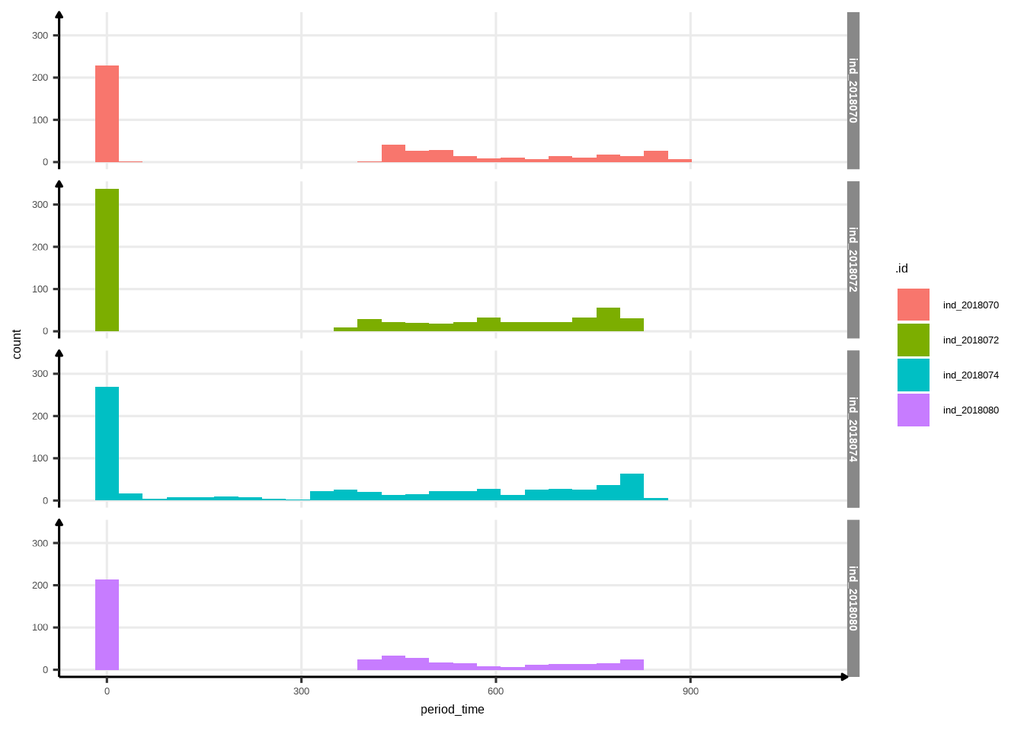

Figure 5: Distributions of the time difference between two rows identified as sunrise and sunset

```r
# display
ggplot(res_twi_inter, aes(x = period_time, fill = .id)) +
  geom_histogram() +
  facet_grid(.id ~ .) +
  theme_jjo()
```

Considering this graph, let’s try to keep rows where `period_time==0` or `300<period_time<900`

```r
# remove outlier (but keep the 0)
res_twi_out <- res_twi[period_time == 0 | period_time %between% c(300, 900)]

# keep only the longer period of time and the row just before
res_twi_out_inter <- res_twi_out[
  c(
    # index of row with the longer period of time
    res_twi_out[, .I[period_time == max(period_time)],
      by = .(.id, as.Date(Twilight))
    ]$V1,
    # index of the row previous the one with the longer period of time
    res_twi_out[, .I[period_time == max(period_time)],
      by = .(.id, as.Date(Twilight))
    ]$V1 - 1
  )
  # reorder by date
] %>%
  # reorder by date
  .[order(Twilight)]
```

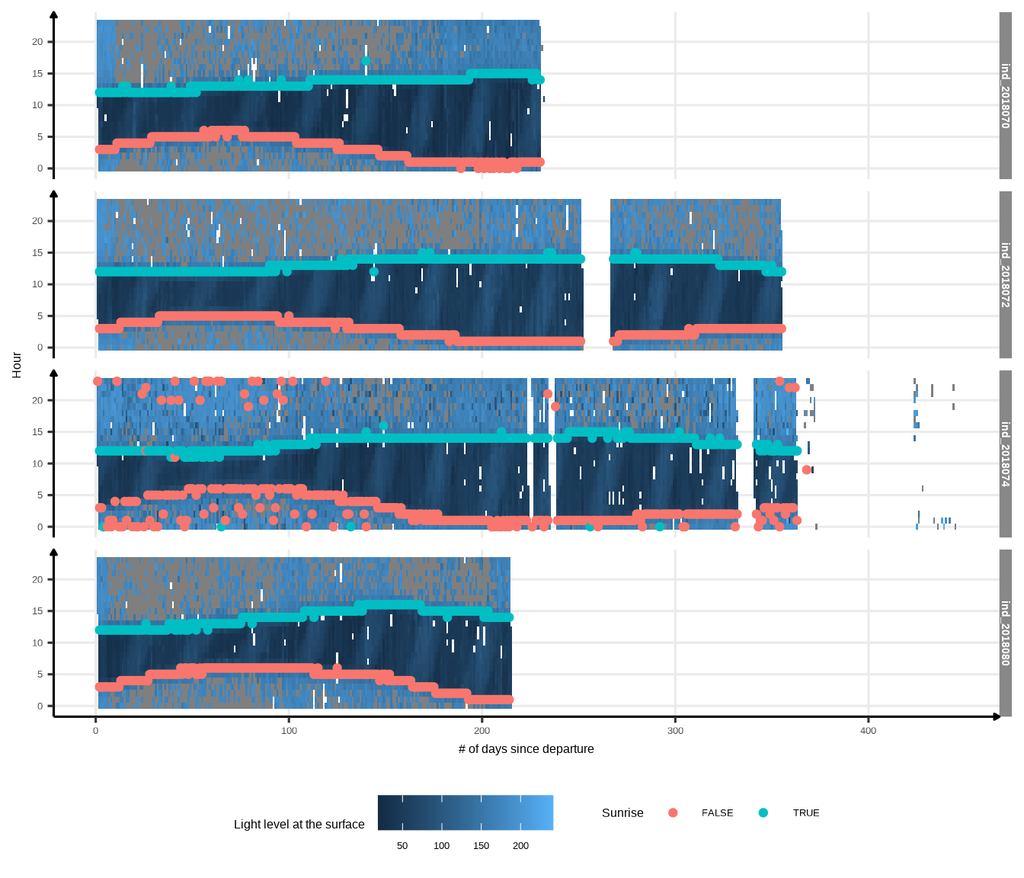

Figure 6: Visualization of light level at the surface along 2018-individuals’ trip, with twilight detection points corrected

```r
# display the result
ggplot() +
  geom_tile(data = dataPlot, aes(x = day_departure, y = hour, fill = lightatsurf)) +
  geom_point(data = res_twi_out_inter, aes(x = day_departure, y = hour, col = Rise)) +
  facet_grid(.id ~ .) +
  theme_jjo() +
  labs(
    x = "# of days since departure",
    y = "Hour",
    fill = "Light level at the surface",
    col = "Sunrise"
  ) +
  theme(legend.position = c("bottom"))
```

> This does not work! If several sunset and sunrise are identified within a day, the current algorithm will only calculates `period_time` between two successive rows, whereas we should test every possible combination.

### Smoothing light level signal

Since those points are due to outliers during the day, we could try to smooth the light level signal and run the `findTwilight` function on it.

```r
# # let's first split our dataset by individual
# split_inter = split(data_2018, data_2018$.id)
#
# # create a times series of ligth level
# split_inter = lapply(split_inter, function(x) {
#   # summerize data at the min level
#   df = x[,.(lightatsurf = median(lightatsurf, na.rm=T)), by=.(date = floor_date(date, unit="min"))]
#   # creation of a time series
#   z = as.ts(zoo(df$lightatsurf, df$date))
#   # smoother creation
#   # https://boostedml.com/2020/05/an-introduction-to-time-series-smoothing-in-r.html
#   s = ksmooth(time(z),as.numeric(z),'normal',bandwidth=6)
#   # retrieve smooth value
#   x[, lightatsurf_smooth := s$y]
# })
#
# # unlist
# data_2018 = rbindlist(split_inter)
```

> So far, I have not been successful using this method cause it seems quite tricky to smooth a signal with a lot of missing values.

## 0.3 Let’s try a clustering method

Since we can visually see where is the day and night time, we should try clustering method.

### 0.3.1 K-MEANS + Hierarchical clustering

Here we test a package well-known to perform clustering `FactoMineR`. The idea behind its main method is to performed a hierarchical clustering where the initial centroids are positioned based on a pre-performed k-means using the first component of a PCA. For more information feel free to have a look at their [website](http://factominer.free.fr/factomethods/hierarchical-clustering-on-principal-components.html).

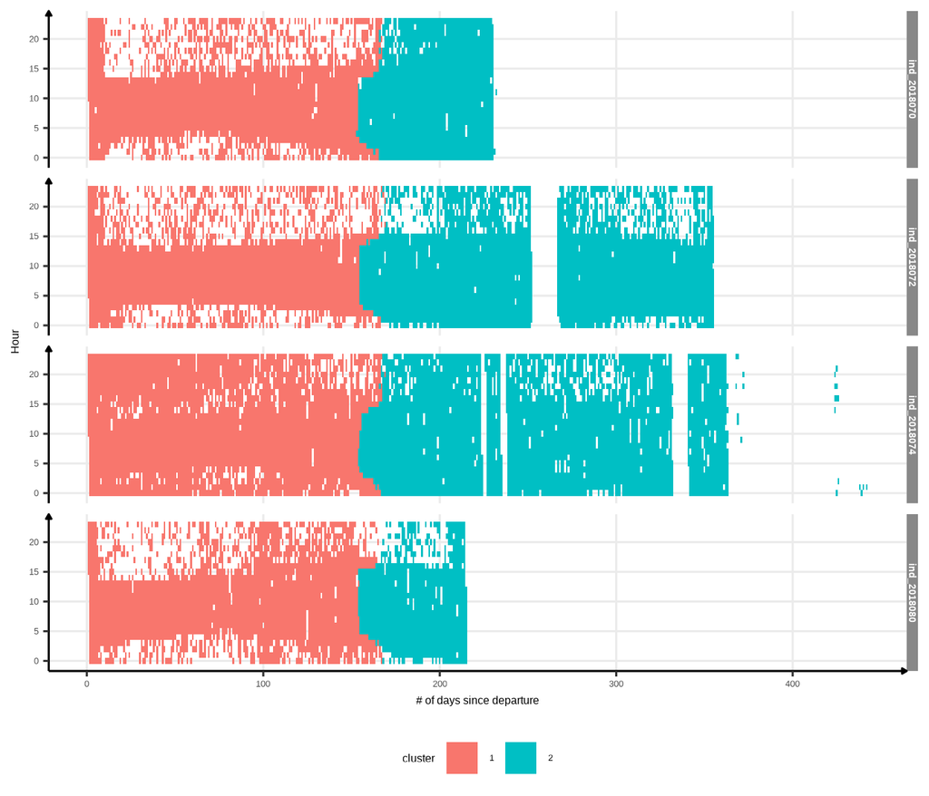

Figure 7: Visualization of the moment where the light was measured at the surface colored with the associated cluster (HCPC)

```r
# remove nan value
df_clust <- dataPlot[!is.na(lightatsurf), .(hour, day_departure, lightatsurf)]

# HCPC with onlys 2 groups
res_hcpc <- FactoMineR::HCPC(df_clust, nb.clust = 2, graph = FALSE)

# display the result
ggplot() +
  geom_tile(
    data = dataPlot[!is.na(lightatsurf), ] %>%
      .[, cluster := res_hcpc$data.clust$clust],
    aes(x = day_departure, y = hour, fill = factor(cluster))
  ) +
  theme_jjo() +
  facet_grid(.id ~ .) +
  labs(
    x = "# of days since departure",
    y = "Hour",
    fill = "cluster",
    col = "Sunrise"
  ) +
  theme(legend.position = c("bottom"))
```

Well, clearly this algorithm is not suited to deal with this kind of patterns!

### 0.3.2 DBSCAN

DBSCAN seems to be an [elegant](http://www.sthda.com/english/wiki/wiki.php?id_contents=7940) algorithm to deal with outliers and non-convex cluster. The only **issue** is that we have to choose the right value for its two parameters:

- Reachability distance
- Reachability minimum number of points

Which might be tricky!

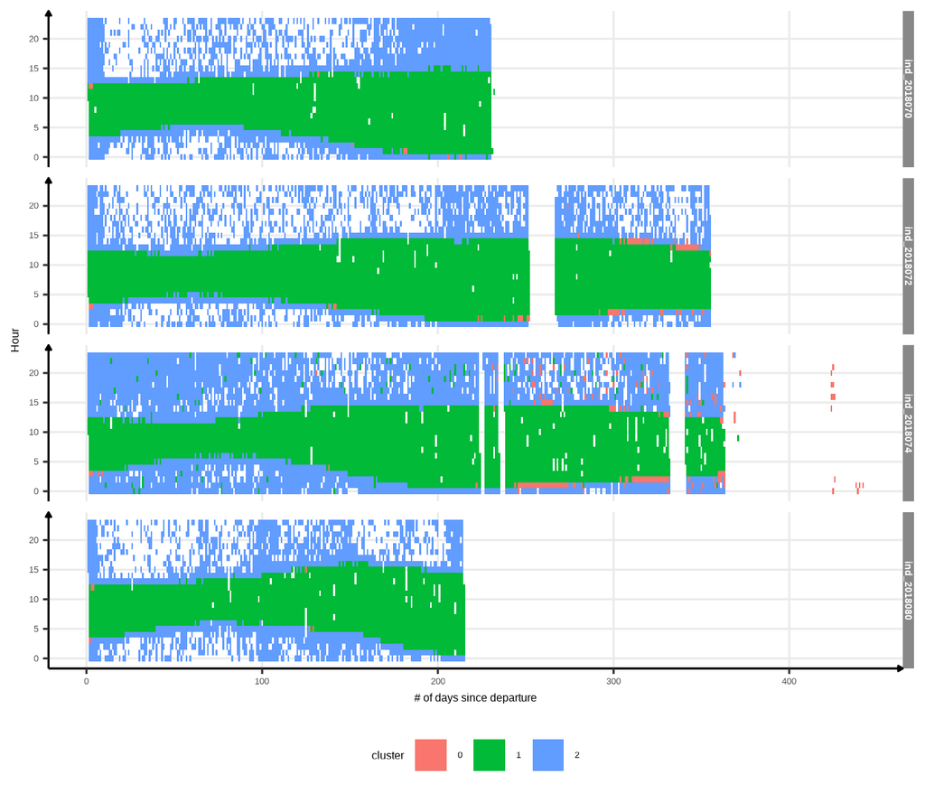

```r
# determine the right values by testing several of them...
res_dbscan <- dbscan(df_clust,
  eps = 21,
  MinPts = nrow(dataPlot) * 0.01,
  method = "raw"
)

# display the result
ggplot() +
  geom_tile(
    data = dataPlot[!is.na(lightatsurf), ][, cluster := res_dbscan$cluster],
    aes(x = day_departure, y = hour, fill = factor(cluster))
  ) +
  theme_jjo() +
  facet_grid(.id ~ .) +
  labs(
    x = "# of days since departure",
    y = "Hour",
    fill = "cluster",
    col = "Sunrise"
  ) +
  theme(legend.position = c("bottom"))
```

Well that’s quite nice :) There are still few outliers (especially for individual `ind_2018074`) identify as cluster 1 whereas we would like to see them in cluster 2.

## 0.4 Conclusion

For now we will used the result from the `DBSCAN` algorithm, since results seem to be better!

```r
# referential creation
ref_phase_day <- dataPlot[!is.na(lightatsurf), ] %>%
  .[, cluster := res_dbscan$cluster] %>%
  .[, cluster := fifelse(cluster == 1, "night", "day")] %>%
  .[]

# reshape
ref_phase_day <- melt(ref_phase_day,
  id.vars = c(".id", "date", "hour"),
  measure.vars = "cluster",
  value.name = "phase"
)

# set date format
ref_phase_day[, `:=`(
  date = date + hours(hour),
  hour = NULL,
  variable = NULL
)]

# rolling join
data_2018 <- ref_phase_day[data_2018, roll = T, on = .(.id, date)]
```

## 0.5 WIP

We could also try to define two other phases of the day:

```r
# identification of transition
ref_phase_day[, transition := c(1, abs(diff(as.numeric(as.factor(phase)))))]

# keep only the first date and the last date (i.e transition) by date and individual
ref_phase_day <- ref_phase_day[transition == 1, .SD[c(1, .N)], by = .(.id, date)]

# convert date to take into account hour
ref_phase_day[, date := date + hours(hour)]

# add sunset
test <- rbind(
  ref_phase_day[, .SD, .SDcols = -c("transition")] %>%
    .[, date := date + minutes(30)],
  ref_phase_day[, .SD, .SDcols = -c("transition")] %>%
    .[phase == "night", ] %>%
    .[, `:=`(
      date = date - minutes(30),
      phase = "sunset"
    )],
  ref_phase_day[, .SD, .SDcols = -c("transition")] %>%
    .[phase == "day", ] %>%
    .[, `:=`(
      date = date - minutes(30),
      phase = "sunrise"
    )]
)
```

> Problem, when there are no day times found during several days, there all marked as night!